# Act report

## Analyzing, and Visualizing WeRateDogs

## Introduction:

This analysis is of tweets from the WeRateDogs twitter account. WeRateDogs is a Twitter account that rates people's dogs with a humorous comment about the dog. It was started in 2015 by college student Matt Nelson

## Analysis:

```python
import pandas as pd
import matplotlib.pyplot as plt
import numpy as np
%matplotlib inline
```

```python
df = pd.read_csv('twitter_archive_master.csv')
df['timestamp']=pd.to_datetime(df['timestamp'])
df.set_index('timestamp', inplace=True)
```

### Question 1

What is the most popular dog breed in our data set?

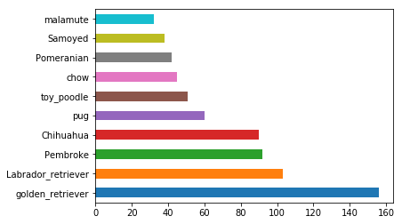

```python
df['dog_type'].value_counts().head(10).plot(kind='barh')
```

### Question 2

*What is the top 10 rating dogs breed on average.*

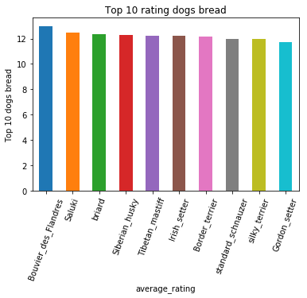

```python
df.groupby('dog_type').rating.mean().sort_values(ascending=False).head(10).plot(kind='bar')
plt.xlabel('average_rating')
plt.ylabel('Top 10 dogs bread')
plt.title('Top 10 rating dogs bread')
plt.xticks(rotation=70)

plt.savefig('top_10_rating_dogs_bread.png')
```

### Question 3

*What is the lowest rating dog breed?* Japanese_spaniel has the lowest rating equal to 5.

```python
df.groupby('dog_type').rating.mean().sort_values(ascending=False).tail(1)
```

```
dog_type
Japanese_spaniel    5.0
Name: rating, dtype: float64
```

### Question 4

[figure not shown]

```python
width=0.4
retweet_mean = df.groupby('dog_stage').retweet_count.mean()
favorite_mean = df.groupby('dog_stage').favorite_count.mean()
x_axis = np.arange(4)
plt.bar(x_axis,retweet_mean,width,alpha=.7,label='Average_ retweet_count')
plt.bar(x_axis+width,favorite_mean,width,alpha=.7,label='Average_favorite_count')
plt.xticks(x_axis+width/2,['doggo','puppo','pupper','floofer'])
plt.legend(bbox_to_anchor=(0.25,1),
           loc='lower left')
plt.savefig('distribution_of_retweet_and_favorite_for_each_dogs_stage.png')
plt.show()
```

### Question 5

Does higher ratings leads to higher retweets or higher favorite count? There is no correlation between rating and retweets or favorites.

```
(0, 20)
```

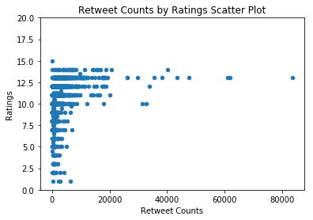

```python
df.plot(x='retweet_count', y='rating', kind='scatter')
plt.title('Retweet Counts by Ratings Scatter Plot')
plt.xlabel('Retweet Counts')
plt.ylabel('Ratings')
plt.savefig('retweet_vs_rating.png')
plt.ylim([0,20])
```

```python
df.retweet_count.corr(df.rating)
```

```
0.02284791547094191
```

```
(0, 20)
```

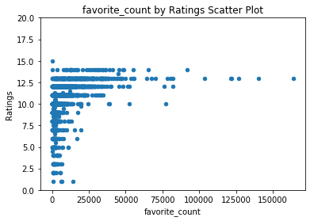

```python
df.plot(x='favorite_count', y='rating', kind='scatter')
plt.title('favorite_count by Ratings Scatter Plot')
plt.xlabel('favorite_count')
plt.ylabel('Ratings')
plt.savefig('favorite_count vs_rating.png')
plt.ylim([0,20])
```

```python
df.favorite_count.corr(df.rating)
```

```
0.022058010947583317
```

### Question 6

Dose higher number of dogs mean higher rating? There is very weak negative relation between rating and number of dogs

```python
df.rating.corr(df.dog_count)
```

```
-0.01653321078463878
```

### Question 7

What is the trend for retweets and favorite over time ? Here you can see the gradual incline of both favorites and retweets.

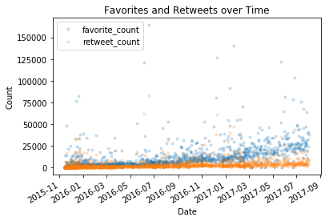

```python
df[['favorite_count', 'retweet_count']].plot(style = '.', alpha = .2)
plt.title('Favorites and Retweets over Time')
plt.xlabel('Date')
plt.ylabel('Count')
```